# Task1

Marcos Crespo

2024-02-10

# Data insights

The MNIST database is a widely used dataset in the field of machine learning and computer vision. It stands for Modified National Institute of Standards and Technology database. It consists of a large collection of handwritten digits. Each observation consists of the label (the intended writen number), the writter id and the $28*28$ greyscale grid values for the image itself. Possible representation of a $0$ could be:

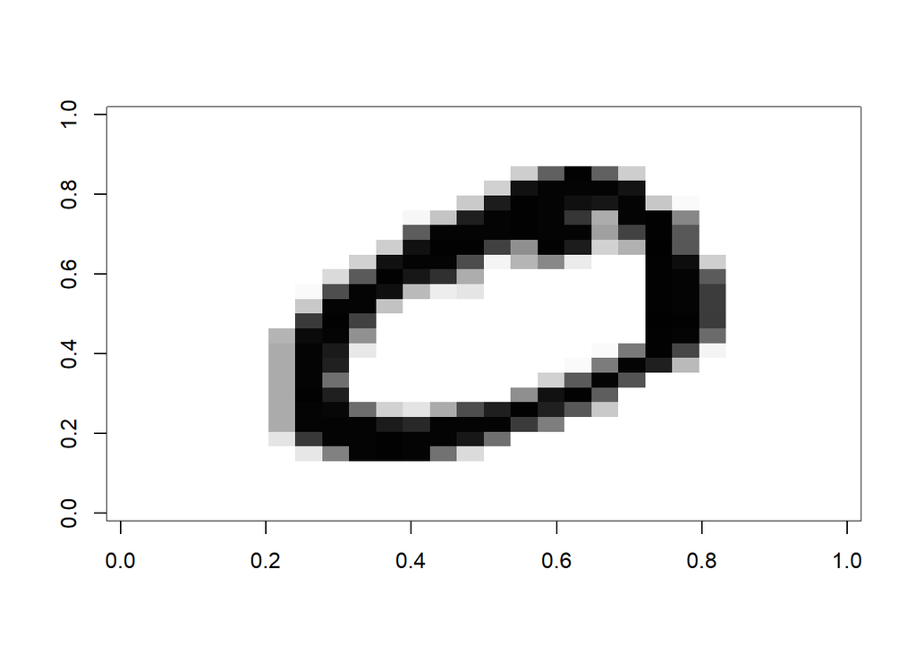

This version of the dataset includes approximately 30,000 training images and 30,000 testing ones. These images are normalized and centered, making them a standard benchmark for evaluating the performance of some algorithms in tasks such as digit recognition and classification[^1].

In the class assignment, we are asked to implement a ridge logistic model for classifying the digits 4 and 9, so our next step is to filter only the data with labels 4 and 9.

```r
# Filter our original data
train <- train_nist %>%
  filter(digit %in% c(4, 9))
```

After running this filtering we end up with 6011 observations of numbers 4 and 9

```r
summary(train[,c(1,2)])
```

```
##      digit          writer
##  9      :3042   14     :  26
##  4      :2969   28     :  26
##  0      :   0   37     :  26
##  1      :   0   40     :  26
##  2      :   0   51     :  26
##  3      :   0   70     :  26
##  (Other):   0   (Other):5855
```

# The model

Ridge regression is a method of estimating the coefficients of multiple-regression models in scenarios where the independent variables are highly correlated.[1] It has been used in many fields including econometrics, chemistry, and engineering.*[WIKIPEDIA]*

The model can be fitted in `glmnet` package